# skew - boundSkew1

## Degree of Skewness

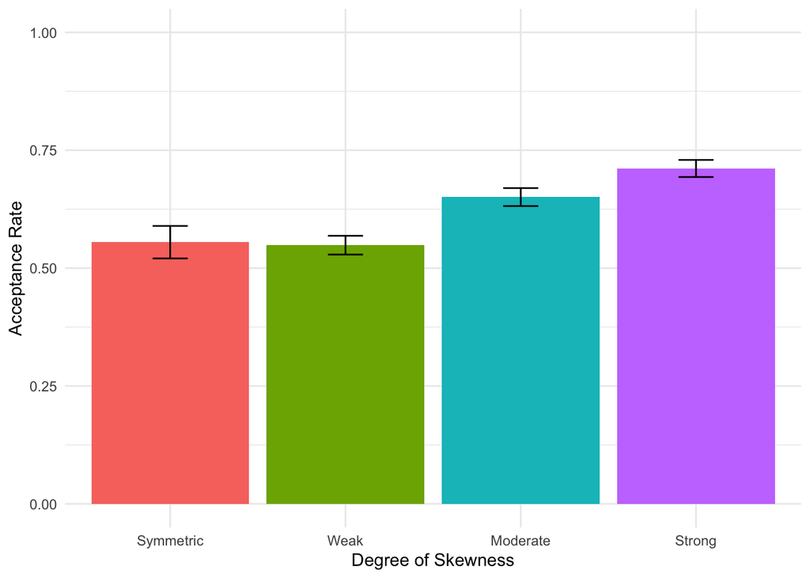

#### With an increase in skewness from weak to strong, gamble acceptance *increases.*

|  | Estimate | Std. Error | z value | Pr(>\|z\|) |
| --- | --- | --- | --- | --- |
| (Intercept) | 0.4679266 | 0.2681298 | 1.7451497 | 0.0809588 |
| deg_skewWeak | -0.0519917 | 0.2153020 | -0.2414828 | 0.8091809 |
| deg_skewModerate | 0.8022525 | 0.2191833 | 3.6601899 | 0.0002520 |
| deg_skewStrong | 1.3519898 | 0.2247179 | 6.0163857 | 0.0000000 |

## Valence

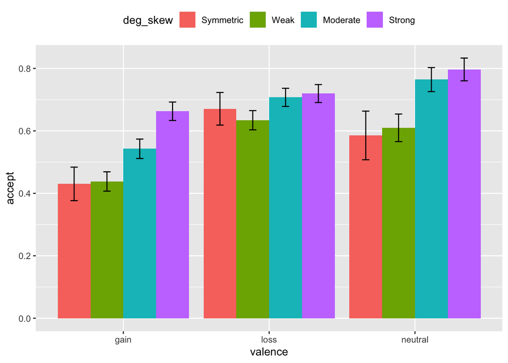

#### The acceptance rates for moderate- and strongly-skewed gambles is greater than symmtetric or weakly-skewed gambles, but this is moderated by valence. Gamble acceptance is similar for all gambles in the loss domain.

|  | Estimate | Std. Error | z value | Pr(>\|z\|) |
| --- | --- | --- | --- | --- |
| (Intercept) | 0.6564071 | 0.6306676 | 1.0408131 | 0.2979623 |
| deg_skewWeak | 0.1991499 | 0.5139225 | 0.3875097 | 0.6983789 |
| deg_skewModerate | 1.6442559 | 0.5471388 | 3.0051898 | 0.0026542 |
| deg_skewStrong | 2.0234853 | 0.5628887 | 3.5948228 | 0.0003246 |
| valencegain | -1.2482512 | 0.7697980 | -1.6215310 | 0.1049038 |
| valenceloss | 0.8278873 | 0.7745278 | 1.0688930 | 0.2851179 |
| deg_skewWeak:valencegain | -0.1314877 | 0.6319594 | -0.2080636 | 0.8351793 |
| deg_skewModerate:valencegain | -0.6791675 | 0.6594580 | -1.0298874 | 0.3030629 |
| deg_skewStrong:valencegain | -0.0020932 | 0.6783353 | -0.0030858 | 0.9975379 |
| deg_skewWeak:valenceloss | -0.4991238 | 0.6315915 | -0.7902636 | 0.4293738 |
| deg_skewModerate:valenceloss | -1.3323002 | 0.6605990 | -2.0168062 | 0.0437157 |
| deg_skewStrong:valenceloss | -1.6039417 | 0.6741617 | -2.3791646 | 0.0173519 |

## Magnitude

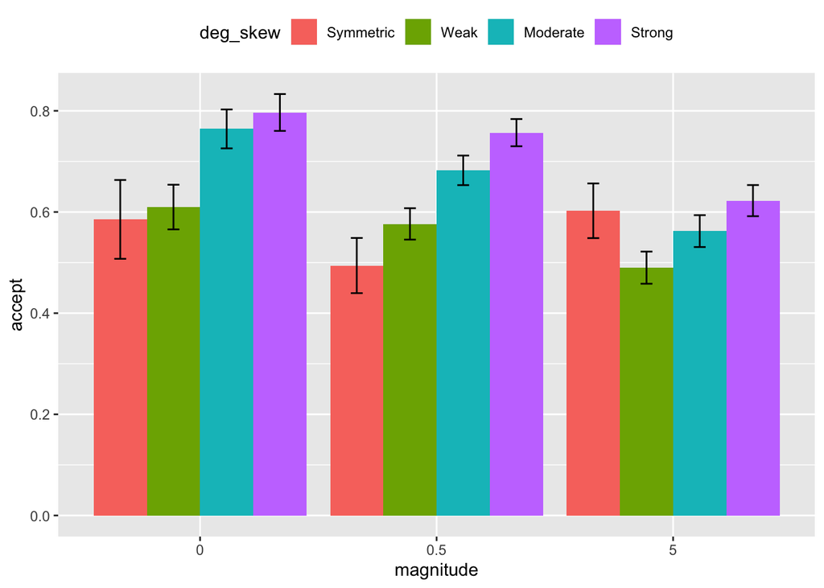

#### Again, the acceptance rates for moderate- and strongly-skewed gambles is greater than symmtetric or weakly-skewed gambles, but this is moderated by magnitude. Gamble acceptance is similar for all high magnitude (EV = /$5) gambles.

|  | Estimate | Std. Error | z value | Pr(>\|z\|) |
| --- | --- | --- | --- | --- |
| (Intercept) | 0.6590337 | 0.6323133 | 1.0422581 | 0.2972920 |
| deg_skewWeak | 0.1993844 | 0.5142703 | 0.3877035 | 0.6982355 |
| deg_skewModerate | 1.6462654 | 0.5476073 | 3.0062883 | 0.0026446 |
| deg_skewStrong | 2.0260184 | 0.5633824 | 3.5961690 | 0.0003229 |
| magnitude0.5 | -0.6204206 | 0.7642441 | -0.8118095 | 0.4169010 |
| magnitude5 | 0.2711988 | 0.7778478 | 0.3486528 | 0.7273500 |
| deg_skewWeak:magnitude0.5 | 0.4428438 | 0.6231587 | 0.7106437 | 0.4773051 |
| deg_skewModerate:magnitude0.5 | -0.1506002 | 0.6543057 | -0.2301679 | 0.8179613 |
| deg_skewStrong:magnitude0.5 | 0.1353558 | 0.6732093 | 0.2010604 | 0.8406513 |
| deg_skewWeak:magnitude5 | -1.1869064 | 0.6402302 | -1.8538745 | 0.0637571 |
| deg_skewModerate:magnitude5 | -2.0013011 | 0.6658652 | -3.0055648 | 0.0026509 |
| deg_skewStrong:magnitude5 | -1.8456031 | 0.6788217 | -2.7188333 | 0.0065513 |

## Magnitude and valence

#### Although a model containing the interaction between magnitude and valence (m3) provides a better fit to the data than a model with valence alone (m1), the model results are somewhat difficult to interpret.

|  | Df | AIC | BIC | logLik | deviance | Chisq | Chi Df | Pr(>Chisq) |
| --- | --- | --- | --- | --- | --- | --- | --- | --- |
| m1 | 13 | 1920.512 | 1993.895 | -947.2558 | 1894.512 | NA | NA | NA |
| m3 | 21 | 1911.088 | 2029.632 | -934.5441 | 1869.088 | 25.42328 | 8 | 0.0013174 |

#### Again, the acceptance rates for moderate- and strongly-skewed gambles is greater than symmtetric or weakly-skewed gambles. However, for losses of $5 does not fit this pattern; here skewed gambles are accepted less than symmetric. Futher, for gains of $5, moderately-skewed gambles are accepted less than strongly-skewed gambles.

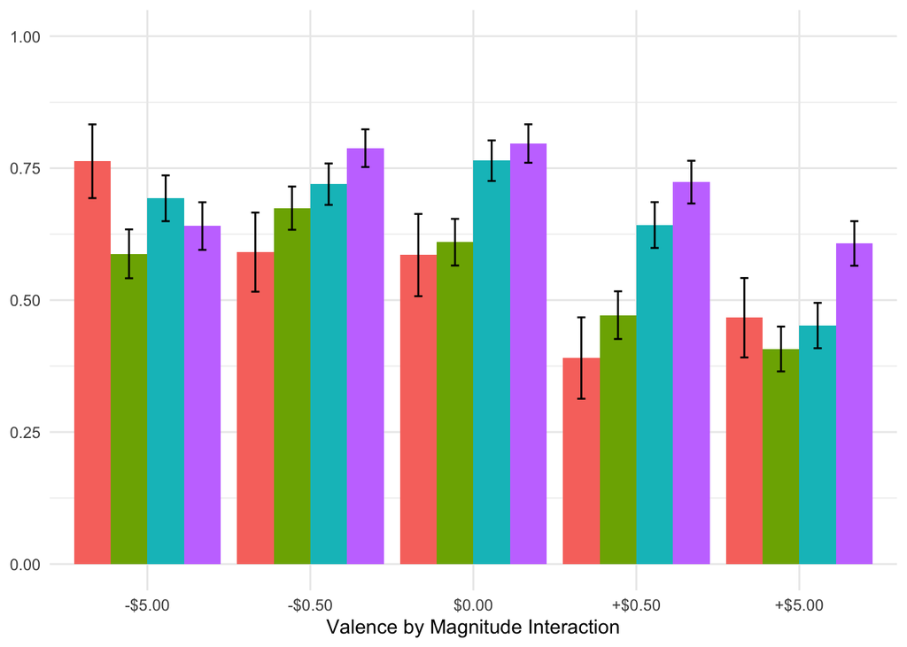

|  | Estimate | Std. Error | z value | Pr(>\|z\|) |
| --- | --- | --- | --- | --- |
| (Intercept) | 0.6612198 | 0.6340936 | 1.0427796 | 0.2970504 |
| deg_skewWeak | 0.1996352 | 0.5147271 | 0.3878466 | 0.6981296 |
| deg_skewModerate | 1.6480066 | 0.5481448 | 3.0065170 | 0.0026426 |
| deg_skewStrong | 2.0282070 | 0.5639240 | 3.5965961 | 0.0003224 |
| magvalloss.5 | 1.6735717 | 0.9438725 | 1.7730907 | 0.0762137 |
| magvalloss.0.5 | 0.1993973 | 0.8791164 | 0.2268156 | 0.8205672 |
| magvalgain.0.5 | -1.4770458 | 0.8893838 | -1.6607519 | 0.0967633 |
| magvalgain.5 | -0.9330725 | 0.8976121 | -1.0395052 | 0.2985698 |
| deg_skewWeak:magvalloss.5 | -1.7291947 | 0.7804105 | -2.2157502 | 0.0267086 |
| deg_skewModerate:magvalloss.5 | -2.3017664 | 0.8023230 | -2.8688773 | 0.0041193 |
| deg_skewStrong:magvalloss.5 | -3.1291918 | 0.8131384 | -3.8482892 | 0.0001189 |
| deg_skewWeak:magvalloss.0.5 | 0.4789363 | 0.7150897 | 0.6697570 | 0.5030127 |
| deg_skewModerate:magvalloss.0.5 | -0.5762835 | 0.7430444 | -0.7755707 | 0.4380025 |
| deg_skewStrong:magvalloss.0.5 | -0.3052627 | 0.7651434 | -0.3989615 | 0.6899216 |
| deg_skewWeak:magvalgain.0.5 | 0.4403261 | 0.7261616 | 0.6063748 | 0.5442659 |
| deg_skewModerate:magvalgain.0.5 | 0.3106505 | 0.7595633 | 0.4089857 | 0.6825502 |
| deg_skewStrong:magvalgain.0.5 | 0.6126624 | 0.7815422 | 0.7839147 | 0.4330902 |
| deg_skewWeak:magvalgain.5 | -0.7880934 | 0.7477971 | -1.0538867 | 0.2919348 |
| deg_skewModerate:magvalgain.5 | -1.7931415 | 0.7684943 | -2.3333180 | 0.0196315 |
| deg_skewStrong:magvalgain.5 | -0.6723173 | 0.7832036 | -0.8584196 | 0.3906608 |